# Life Expectancy Project

R Code for Socioeconomic Determinants of Life Expectancy: A 2019 Analysis Across U.S. States

Introduction:

In this project we will analyse the factors that affect life expectancy (response variable).The training data from 2018 will be used in different models to predict life expectancy the following year. The model with the least variance from the actual 2019 data will be chosen.

The table bellow represents the dependent and independent variables that will be analyzed and a desciption what they mean. Life Expentancy is the dependent/response variable in this analysis.

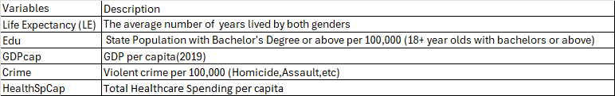

```r
library(readr)

LE2018 <- read_csv(
  "C:/Users/surface/OneDrive - SNHU/Aggregate of 2018 Data.csv",
  show_col_types = FALSE
)

LE2018 <- LE2018[, 1:7]

# View the data
View(LE2018)
cat('\n\n')
```

A tibble: 50 × 7

| States <chr> | Population <dbl> | LE <dbl> | Edu <dbl> | GDPcap <dbl> | Crime <dbl> | HealthSpCap <dbl> |
| --- | --- | --- | --- | --- | --- | --- |
| Alabama | 4891628 | 75.1 | 18168 | 45329.59 | 523 | 8418 |
| Alaska | 736624 | 78.0 | 20402 | 74303.99 | 890 | 14051 |
| Arizona | 7164228 | 78.7 | 20902 | 48616.14 | 475 | 7923 |
| Arkansas | 3012161 | 75.6 | 16385 | 42633.48 | 561 | 9237 |
| California | 39437463 | 80.8 | 24351 | 76012.32 | 448 | 9574 |
| Colorado | 5697155 | 80.0 | 29863 | 65251.80 | 401 | 8446 |
| Connecticut | 3574561 | 80.4 | 29179 | 77135.88 | 209 | 11365 |
| Delaware | 966985 | 77.8 | 22797 | 75990.11 | 422 | 11984 |
| Florida | 21254926 | 78.9 | 22658 | 48893.89 | 386 | 9603 |
| Georgia | 10519389 | 77.2 | 22138 | 56291.62 | 339 | 8190 |
| Hawaii | 1423102 | 81.0 | 24186 | 65910.88 | 255 | 8844 |
| Idaho | 1752074 | 79.0 | 18720 | 43977.59 | 239 | 8399 |
| Illinois | 12724685 | 78.8 | 25363 | 68002.50 | 411 | 9802 |
| Indiana | 6698481 | 76.8 | 19089 | 54758.76 | 373 | 10058 |
| Iowa | 3149900 | 79.2 | 20628 | 60224.64 | 264 | 9486 |
| Kansas | 2912748 | 78.0 | 23309 | 57786.67 | 442 | 9044 |
| Kentucky | 4464273 | 75.3 | 17722 | 46611.73 | 218 | 9713 |
| Louisiana | 4664450 | 75.6 | 16957 | 55159.30 | 543 | 9464 |
| Maine | 1340123 | 78.6 | 24057 | 48395.56 | 112 | 11381 |
| Maryland | 6042153 | 78.5 | 29431 | 68284.30 | 469 | 10099 |
| Massachusetts | 6885720 | 80.1 | 33166 | 82705.66 | 340 | 12050 |
| Michigan | 9987286 | 77.7 | 21418 | 52776.68 | 452 | 9532 |
| Minnesota | 5608762 | 80.5 | 26191 | 65763.60 | 221 | 10670 |
| Mississippi | 2982879 | 74.6 | 16072 | 38497.77 | 266 | 9016 |
| Missouri | 6125986 | 76.6 | 21148 | 52060.35 | 501 | 9708 |
| Montana | 1061818 | 78.7 | 23006 | 47396.63 | 380 | 10048 |
| Nebraska | 1925512 | 79.1 | 22621 | 64386.98 | 290 | 10263 |
| Nevada | 3030725 | 77.9 | 17677 | 55864.49 | 552 | 8065 |
| New Hampshire | 1355064 | 79.1 | 27720 | 62332.04 | 177 | 11367 |
| New Jersey | 8891730 | 79.8 | 29941 | 69952.96 | 208 | 10673 |
| New Mexico | 2093754 | 77.2 | 19297 | 47902.86 | 842 | 8662 |
| New York | 19544098 | 80.5 | 27612 | 85389.77 | 351 | 12218 |
| North Carolina | 10391358 | 77.6 | 22881 | 54246.09 | 356 | 8843 |
| North Dakota | 760062 | 79.3 | 20645 | 73786.48 | 283 | 12037 |
| Ohio | 11680892 | 76.8 | 20906 | 57864.18 | 295 | 10147 |
| Oklahoma | 3943488 | 75.6 | 17643 | 51364.20 | 474 | 9144 |
| Oregon | 4183538 | 79.7 | 24856 | 57315.79 | 290 | 9800 |
| Pennsylvania | 12809107 | 78.1 | 23551 | 61141.48 | 305 | 11111 |
| Rhode Island | 1059338 | 79.8 | 25601 | 57193.83 | 220 | 10754 |
| South Carolina | 5091702 | 76.5 | 20275 | 45943.36 | 500 | 8603 |
| South Dakota | 879386 | 78.9 | 20425 | 59149.11 | 396 | 11887 |
| Tennessee | 6778180 | 75.5 | 19753 | 53717.21 | 630 | 8634 |
| Texas | 28624564 | 78.4 | 20461 | 62970.78 | 413 | 8404 |
| Utah | 3155153 | 79.6 | 21482 | 56459.26 | 239 | 7104 |
| Vermont | 624802 | 79.3 | 29025 | 53226.94 | 185 | 11500 |
| Virginia | 8510920 | 79.0 | 28221 | 62612.80 | 204 | 9084 |
| Washington | 7526793 | 80.0 | 26440 | 75175.58 | 315 | 9607 |
| West Virginia | 1805953 | 74.4 | 15927 | 42879.08 | 300 | 11912 |
| Wisconsin | 5809319 | 79.3 | 21795 | 57888.71 | 299 | 10244 |
| Wyoming | 579054 | 78.1 | 18917 | 67555.88 | 213 | 10033 |

Scatter plots of Life Expectancy vs each independent variable.

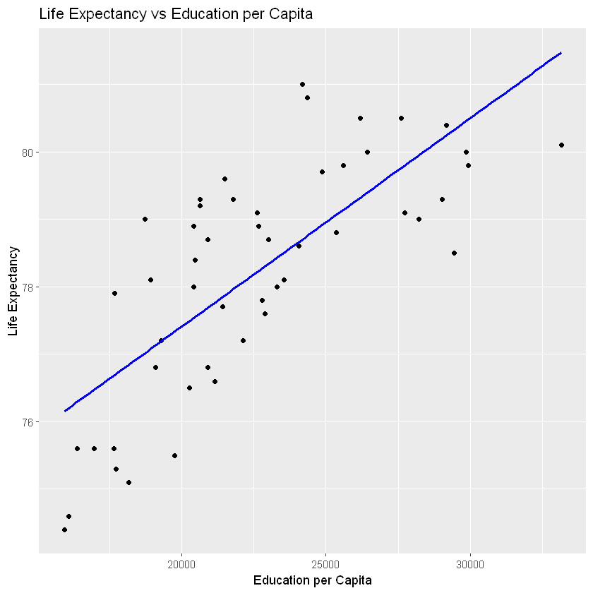

```r
cat('\n\n')
library(ggplot2)
ggplot(LE2018, aes(x = Edu, y = LE)) +
  geom_point() +
  geom_smooth(method = "lm", color = "blue", se = FALSE) +
  labs(x = "Education per Capita", y = "Life Expectancy", title = "Life Expectancy vs Education per Capita")
```

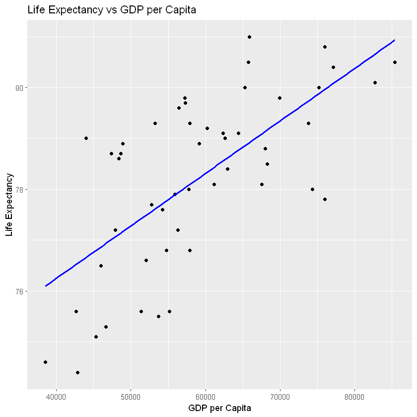

```r
cat('\n\n')
ggplot(LE2018, aes(x = GDPcap, y = LE)) +
  geom_point() +
  geom_smooth(method = "lm", color = "blue", se = FALSE) +
  labs(x = "GDP per Capita", y = "Life Expectancy", title = "Life Expectancy vs GDP per Capita")
```

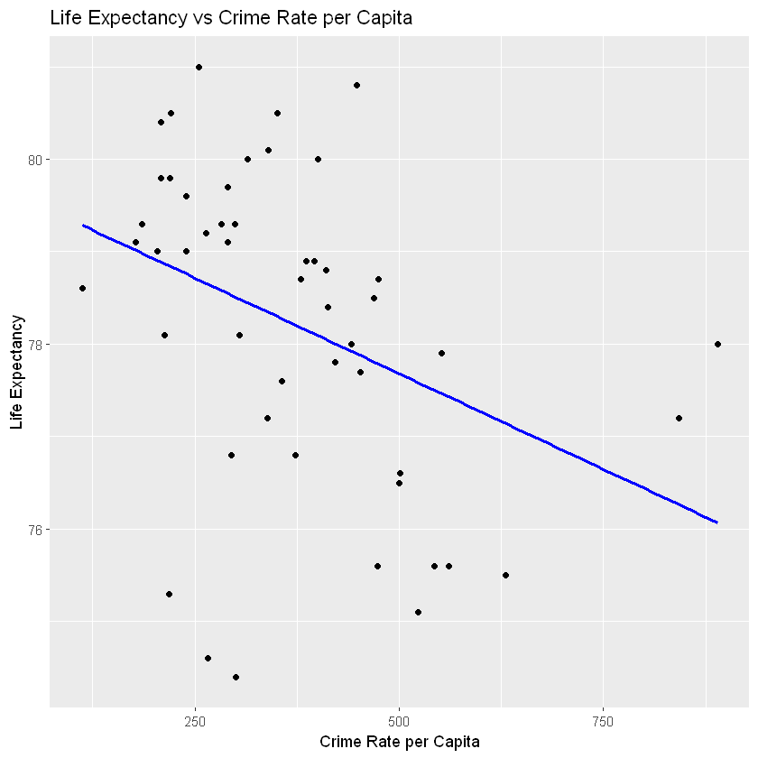

```r
cat('\n\n')
ggplot(LE2018, aes(x = Crime, y = LE)) +
  geom_point() +
  geom_smooth(method = "lm", color = "blue", se = FALSE) +
  labs(x = "Crime Rate per Capita", y = "Life Expectancy", title = "Life Expectancy vs Crime Rate per Capita")
```

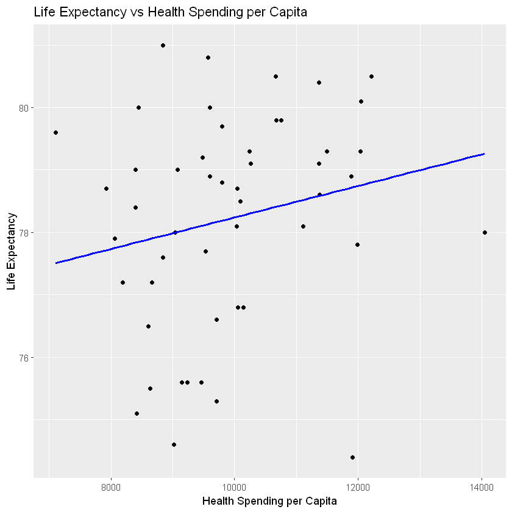

```r
cat('\n\n')
ggplot(LE2018, aes(x = HealthSpCap, y = LE)) +
  geom_point() +
  geom_smooth(method = "lm", color = "blue", se = FALSE) +
  labs(x = "Health Spending per Capita", y = "Life Expectancy", title = "Life Expectancy vs Health Spending per Capita")
```

Correlation between Life Expectancy and Idependent variables

```r
cat("Life Expectancy and Education per Capita\n")
cor(LE2018$LE,LE2018$Edu)
```

```
Life Expectancy and Education per Capita
```

0.744813431984453

```r
cat("Life Expectancy and GDP per Capita\n")
cor(LE2018$LE,LE2018$GDPcap)
```

```
Life Expectancy and GDP per Capita
```

0.665542172014964

```r
cat("Life Expectancy and Crime per Capita\n")
cor(LE2018$LE,LE2018$Crime)
```

```
Life Expectancy and Crime per Capita
```

-0.377316768991331

```r
cat("Life Expectancy and Health Spending per Capita\n")
cor(LE2018$LE,LE2018$HealthSpCap)
cat('\n')
```

```
Life Expectancy and Health Spending per Capita
```

0.204663720478707

First Order Regression

```r
model1 <- lm(LE ~ Edu + GDPcap + Crime + HealthSpCap, data = LE2018)
summary(model1)
cat('\n\n')
```

```
Call:
lm(formula = LE ~ Edu + GDPcap + Crime + HealthSpCap, data = LE2018)

Residuals:
    Min      1Q  Median      3Q     Max
-1.5369 -0.9282 -0.2015  0.9879  1.9395

Coefficients:
              Estimate Std. Error t value Pr(>|t|)
(Intercept)  7.287e+01  1.378e+00  52.870  < 2e-16 ***
Edu          1.812e-04  5.122e-05   3.537 0.000951 ***
GDPcap       6.927e-05  1.957e-05   3.539 0.000946 ***
Crime       -2.151e-03  1.042e-03  -2.064 0.044825 *
HealthSpCap -2.058e-04  1.226e-04  -1.679 0.100126
---
Signif. codes:  0 '***' 0.001 '**' 0.01 '*' 0.05 '.' 0.1 ' ' 1

Residual standard error: 1.04 on 45 degrees of freedom
Multiple R-squared:  0.6626,	Adjusted R-squared:  0.6327
F-statistic:  22.1 on 4 and 45 DF,  p-value: 3.834e-10
```

Multicollinearity Variance Inflation Factor (VIF) Test:

Note: If the VIF is less than 5, the variables are generally not considered to be collinear,

and thus, the variable can be retained in the model without concerns of serious multicollinearity affecting the regression coefficients' stability.

```r
library(car)
vif_values <- vif(model1)
cat('\n')
print(vif_values)
cat('\n\n')
```

```
        Edu      GDPcap       Crime HealthSpCap
   2.034756    2.126286    1.205457    1.317235
```

We will use the 2019 variables to predict theoretical Life Expectancies for each state Using the Linear Regression Model

```r
library(readr)
LE2019 <- read_csv("C:/Users/surface/OneDrive - SNHU/Aggregate of Data 2019.csv")

newdata <- LE2019[, c("Edu", "Crime", "GDPcap","HealthSpCap")]
cat('\n\n')
print("Predictions using Linear regression ")
predictmodel1<- predict(model1,newdata)
round(predictmodel1, 1)
```

```
[1] "Predictions using Linear regression "
```

**1**

76.6

**2**

76.9

**3**

77.6

**4**

75.7

**5**

79.9

**6**

80.5

**7**

81

**8**

79.2

**9**

77.7

**10**

78.5

**11**

79.6

**12**

77.3

**13**

79.5

**14**

77.3

**15**

78.3

**16**

78.4

**17**

77

**18**

76.8

**19**

78.3

**20**

80

**21**

81.7

**22**

77.6

**23**

79.6

**24**

75.9

**25**

77.4

**26**

77.6

**27**

78.8

**28**

77.4

**29**

79.7

**30**

80.7

**31**

76.2

**32**

80.8

**33**

78.3

**34**

78.8

**35**

78

**36**

76.9

**37**

78.9

**38**

78.6

**39**

79

**40**

77.1

**41**

77.4

**42**

77.4

**43**

78.5

**44**

78.8

**45**

79.1

**46**

80.1

**47**

80.5

**48**

75.5

**49**

78.3

**50**

78.7

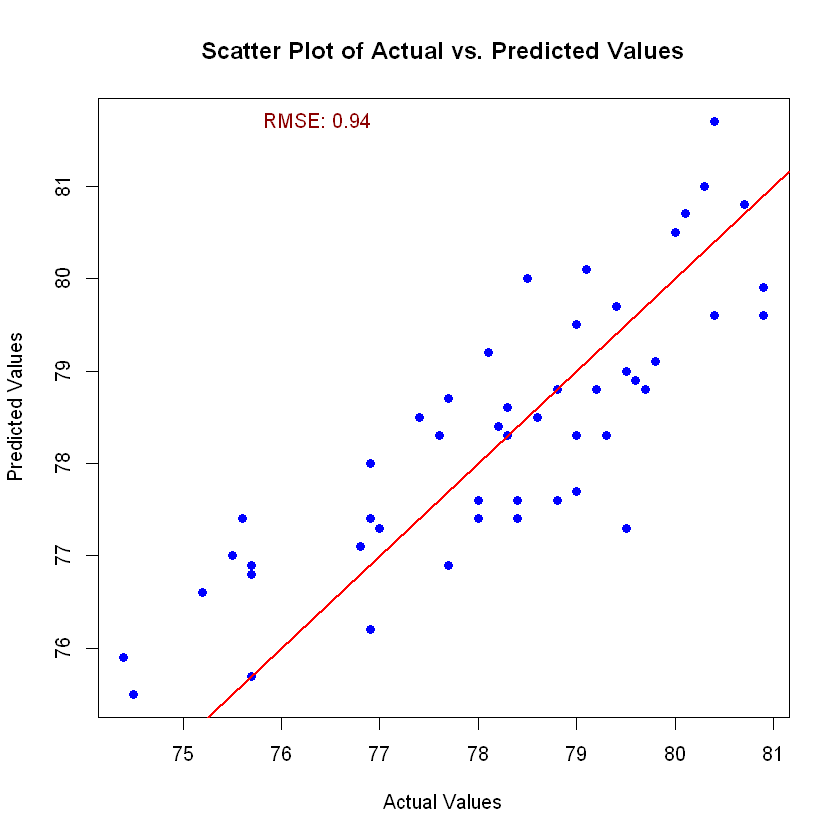

```r
LE2019LinearPred <- c(76.6, 76.9, 77.6, 75.7, 79.9, 80.5, 81.0, 79.2, 77.7, 78.5, 79.6, 77.3, 79.5, 77.3, 78.3, 78.4, 77.0, 76.8, 78.3, 80.0, 81.7, 77.6, 79.6, 75.9, 77.4, 77.6, 78.8, 77.4, 79.7, 80.7, 76.2, 80.8, 78.3, 78.8, 78.0, 76.9, 78.9, 78.6, 79.0, 77.1, 77.4, 77.4, 78.5, 78.8, 79.1, 80.1, 80.5, 75.5, 78.3, 78.7)
LE2018$PredLE2019Linear <- LE2019LinearPred
LE2018$ActualLE2019 <- LE2019[,3]
LE2018$ActualLE2019 <- as.numeric(LE2018$ActualLE2019$LE)
actual_values <- LE2018$ActualLE2019  # Actual Life Expectancy values
predicted_values <- LE2018$PredLE2019Linear

plot(actual_values, predicted_values,
     xlab = "Actual Values", ylab = "Predicted Values",
     main = "Scatter Plot of Actual vs. Predicted Values",
     pch = 19, col = "blue")  # pch = 19 makes the points solid; col = "blue" colors them blue

# Add a 45-degree line to indicate where actual equals predicted
abline(0, 1, col = "red", lwd = 2)  # lwd = 2 makes the line a bit thicker for visibility

# Optionally, add text to display the RMSE value on the plot
rmse_value <- sqrt(mean((actual_values - predicted_values)^2, na.rm = TRUE))  # Calculate RMSE
text(x = quantile(actual_values, 0.1), y = max(predicted_values), labels = paste("RMSE:", round(rmse_value, 2)), pos = 4, col = "darkred")
```

First order Regression RMSE = 0.94

First-order Regression with Interactions The interaction model below was selected because it gave the largest R^2 value out of all other First order Interation combination.

```r
modelWint <- lm(LE ~ HealthSpCap + Crime + GDPcap + Edu +
               HealthSpCap:Crime + HealthSpCap:GDPcap + HealthSpCap:Edu +
               Crime:GDPcap + Crime:Edu + GDPcap:Edu,
               data = LE2018)

summary(modelWint)
cat("\n\n")
```

```
Call:
lm(formula = LE ~ HealthSpCap + Crime + GDPcap + Edu + HealthSpCap:Crime +
    HealthSpCap:GDPcap + HealthSpCap:Edu + Crime:GDPcap + Crime:Edu +
    GDPcap:Edu, data = LE2018)

Residuals:
     Min       1Q   Median       3Q      Max
-1.44129 -0.74935  0.07754  0.66228  1.98319

Coefficients:
                     Estimate Std. Error t value Pr(>|t|)
(Intercept)         6.849e+01  8.623e+00   7.943 1.13e-09 ***
HealthSpCap        -1.165e-03  8.990e-04  -1.296   0.2026
Crime              -4.584e-03  9.199e-03  -0.498   0.6211
GDPcap              2.380e-04  2.075e-04   1.147   0.2583
Edu                 6.069e-04  5.195e-04   1.168   0.2498
HealthSpCap:Crime   6.751e-07  9.673e-07   0.698   0.4894
HealthSpCap:GDPcap  6.647e-09  1.615e-08   0.412   0.6829
HealthSpCap:Edu     1.446e-08  4.746e-08   0.305   0.7623
Crime:GDPcap       -9.596e-08  1.688e-07  -0.569   0.5729
Crime:Edu           4.192e-08  3.946e-07   0.106   0.9159
GDPcap:Edu         -9.332e-09  3.485e-09  -2.678   0.0108 *
---
Signif. codes:  0 '***' 0.001 '**' 0.01 '*' 0.05 '.' 0.1 ' ' 1

Residual standard error: 1 on 39 degrees of freedom
Multiple R-squared:  0.7299,	Adjusted R-squared:  0.6607
F-statistic: 10.54 on 10 and 39 DF,  p-value: 2.434e-08
```

The Multicollinearity VIF is larger than 5, which means collinearity definitely exists. This however does not negatively affect the model's predictive capabilities, as can be seen by the RMSE value below.

```r
library(car)
vif_values2 <- vif(modelWint)
cat('\n')
print(vif_values2)
cat('\n\n')
```

```
there are higher-order terms (interactions) in this model
consider setting type = 'predictor'; see ?vif
```

```
       HealthSpCap              Crime             GDPcap                Edu
          76.68192          101.62926          258.59931          226.57626
 HealthSpCap:Crime HealthSpCap:GDPcap    HealthSpCap:Edu       Crime:GDPcap
         139.82351          388.45032          397.54208          137.34815
         Crime:Edu         GDPcap:Edu
          73.55410          126.95784
```

```r
print("Predictions using Linear regression with Interaction")
predictmodel2<- predict(modelWint,newdata)
round(predictmodel2, 1)
```

```
[1] "Predictions using Linear regression with Interaction"
```

**1**

76.5

**2**

78.1

**3**

77.8

**4**

75.2

**5**

79.3

**6**

80

**7**

80.4

**8**

79.3

**9**

78.1

**10**

78.8

**11**

79.6

**12**

77.4

**13**

79.3

**14**

77.3

**15**

78.6

**16**

78.6

**17**

76.6

**18**

76.7

**19**

78.6

**20**

79.6

**21**

80

**22**

77.8

**23**

79.7

**24**

75

**25**

77.6

**26**

78.2

**27**

79

**28**

77.3

**29**

79.9

**30**

80.3

**31**

76.1

**32**

80

**33**

78.5

**34**

79.2

**35**

78.2

**36**

76.8

**37**

79.2

**38**

78.8

**39**

79.3

**40**

77.4

**41**

77.5

**42**

77.4

**43**

78.5

**44**

79.3

**45**

79.7

**46**

80.3

**47**

80

**48**

74.1

**49**

78.6

**50**

79.1

```r
LE2019LinearPredWint <- c(
    76.5, 78.1, 77.8, 75.2, 79.3, 80.0, 80.4, 79.3, 78.1, 78.8,
    79.6, 77.4, 79.3, 77.3, 78.6, 78.6, 76.6, 76.7, 78.6, 79.6,
    80.0, 77.8, 79.7, 75.0, 77.6, 78.2, 79.0, 77.3, 79.9, 80.3,
    76.1, 80.0, 78.5, 79.2, 78.2, 76.8, 79.2, 78.8, 79.3, 77.4,
    77.5, 77.4, 78.5, 79.3, 79.7, 80.3, 80.0, 74.1, 78.6, 79.1
)
```

[figure not shown]

```r
LE2018$PredLE2019LinearWint <- LE2019LinearPredWint
LE2018$ActualLE2019 <- LE2019[,3]
LE2018$ActualLE2019 <- as.numeric(LE2018$ActualLE2019$LE)
actual_values <- LE2018$ActualLE2019  # Actual Life Expectancy values
predicted_values2 <- LE2018$PredLE2019LinearWint

plot(actual_values, predicted_values,
     xlab = "Actual Values", ylab = "Predicted Values",
     main = "Scatter Plot of Actual vs. Predicted Values",
     pch = 19, col = "blue")  # pch = 19 makes the points solid; col = "blue" colors them blue

# Add a 45-degree line to indicate where actual equals predicted
abline(0, 1, col = "red", lwd = 2)  # lwd = 2 makes the line a bit thicker for visibility

# Optionally, add text to display the RMSE value on the plot
rmse_value <- sqrt(mean((actual_values - predicted_values2)^2, na.rm = TRUE))  # Calculate RMSE
text(x = quantile(actual_values, 0.1), y = max(predicted_values2), labels = paste("RMSE:", round(rmse_value, 2)), pos = 4, col = "darkred")
```

First-order Regression with Interactions RMSE = 0.85

Second Order Regression

```r
model3 <- lm(LE ~ I(Edu) + I(Edu^2) + I(GDPcap) + I(GDPcap^2) + I(Crime) + I(Crime^2) + HealthSpCap, data = LE2018)
summary(model3)
cat('\n\n')
```

```
Call:
lm(formula = LE ~ I(Edu) + I(Edu^2) + I(GDPcap) + I(GDPcap^2) +
    I(Crime) + I(Crime^2) + HealthSpCap, data = LE2018)

Residuals:
    Min      1Q  Median      3Q     Max
-1.5905 -0.5947 -0.1095  0.6365  1.7831

Coefficients:
              Estimate Std. Error t value Pr(>|t|)
(Intercept)  6.273e+01  4.746e+00  13.216  < 2e-16 ***
I(Edu)       1.470e-03  3.771e-04   3.898 0.000343 ***
I(Edu^2)    -2.711e-08  7.804e-09  -3.475 0.001201 **
I(GDPcap)   -3.539e-05  1.374e-04  -0.258 0.797963
I(GDPcap^2)  8.251e-10  1.112e-09   0.742 0.462143
I(Crime)    -7.739e-03  3.632e-03  -2.131 0.038971 *
I(Crime^2)   6.110e-06  3.703e-06   1.650 0.106351
HealthSpCap -2.466e-04  1.220e-04  -2.021 0.049641 *
---
Signif. codes:  0 '***' 0.001 '**' 0.01 '*' 0.05 '.' 0.1 ' ' 1

Residual standard error: 0.9089 on 42 degrees of freedom
Multiple R-squared:  0.7597,	Adjusted R-squared:  0.7197
F-statistic: 18.97 on 7 and 42 DF,  p-value: 3.819e-11
```

The Multicollinearity VIF is larger than 5, which means collinearity exists. However, this does not negatively affect the model's predictive capabilities, as seen by the RMSE value below.

```r
library(car)
vif_values3 <- vif(model3)
cat('\n')
print(vif_values3)
cat('\n\n')
```

```
     I(Edu)    I(Edu^2)   I(GDPcap) I(GDPcap^2)    I(Crime)  I(Crime^2)
 144.578079  139.415309  137.228220  136.488610   19.175886   18.382087
HealthSpCap
   1.710232
```

```r
print("Predictions using Second Order Regression")
predictmodel3<- predict(model3,newdata)
round(predictmodel3, 1)
```

```
[1] "Predictions using Second Order Regression"
```

**1**

76.4

**2**

77.8

**3**

77.8

**4**

74.9

**5**

80.3

**6**

79.5

**7**

80.9

**8**

79.4

**9**

78.1

**10**

78.9

**11**

80

**12**

77.7

**13**

79.7

**14**

76.9

**15**

78.5

**16**

78.7

**17**

76.8

**18**

76

**19**

79.2

**20**

79.3

**21**

79.7

**22**

77.8

**23**

79.9

**24**

75

**25**

77.6

**26**

78

**27**

79.1

**28**

76.9

**29**

79.9

**30**

80.1

**31**

77

**32**

80.9

**33**

78.6

**34**

79

**35**

78.2

**36**

76.4

**37**

79.2

**38**

78.9

**39**

79.4

**40**

77.4

**41**

77.2

**42**

77.6

**43**

78.5

**44**

79.3

**45**

79

**46**

80.1

**47**

80.8

**48**

74.4

**49**

78.6

**50**

79

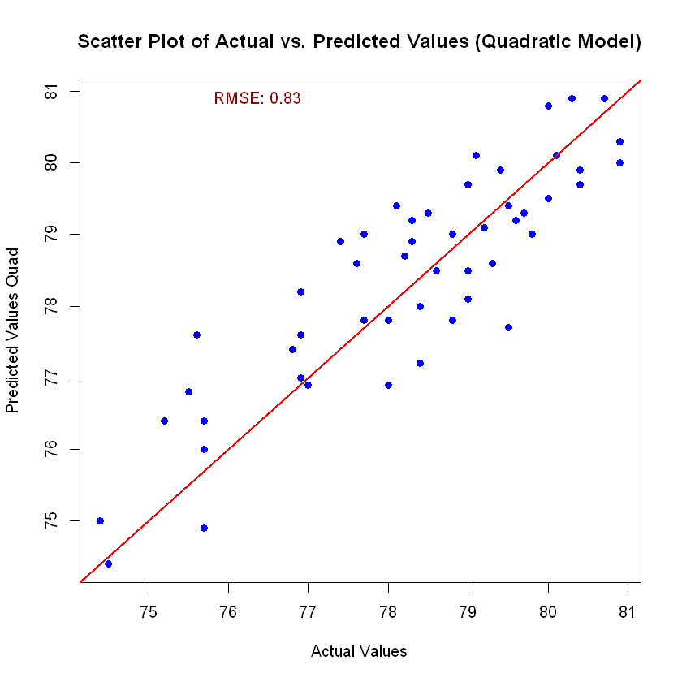

```r
LE2019quadratic <- c(76.4, 77.8, 77.8, 74.9, 80.3, 79.5, 80.9, 79.4, 78.1, 78.9, 80.0, 77.7, 79.7, 76.9, 78.5, 78.7, 76.8, 76.0, 79.2, 79.3, 79.7, 77.8, 79.9, 75.0, 77.6, 78.0, 79.1, 76.9, 79.9, 80.1, 77.0, 80.9, 78.6, 79.0, 78.2, 76.4, 79.2, 78.9, 79.4, 77.4, 77.2, 77.6, 78.5, 79.3, 79.0, 80.1, 80.8, 74.4, 78.6, 79.0)
LE2018$PredLE2019Quad <- LE2019quadratic
predicted_values_quad3 <- LE2018$PredLE2019Quad  # Predicted values from the quadratic model

# Create the scatter plot for the quadratic model predictions
plot(actual_values, predicted_values_quad3,
     xlab = "Actual Values", ylab = "Predicted Values Quad",
     main = "Scatter Plot of Actual vs. Predicted Values (Quadratic Model)",
     pch = 19, col = "blue")  # pch = 19 makes the points solid; col = "blue" colors them blue

# Add a 45-degree line to indicate where actual equals predicted
abline(0, 1, col = "red", lwd = 2)  # lwd = 2 makes the line a bit thicker for visibility

# Calculate RMSE for the quadratic model and add it to the plot
rmse_value_quad <- sqrt(mean((actual_values - predicted_values_quad3)^2, na.rm = TRUE))
text(x = quantile(actual_values, 0.1), y = max(predicted_values_quad3), labels = paste("RMSE:", round(rmse_value_quad, 2)), pos = 4, col = "darkred")
```

Second Order Regression RMSE = 0.83

Second Order Regression with Interactions

```r
modelz <- lm(LE ~ HealthSpCap + Crime + GDPcap + Edu +
              I(HealthSpCap^2) + I(Crime^2) + I(GDPcap^2) + I(Edu^2) +
              HealthSpCap:Crime + HealthSpCap:GDPcap + HealthSpCap:Edu +
              Crime:GDPcap + Crime:Edu + GDPcap:Edu +
              Crime:I(HealthSpCap^2) + GDPcap:I(HealthSpCap^2) + Edu:I(HealthSpCap^2) +
              HealthSpCap:I(Crime^2) + HealthSpCap:I(GDPcap^2) + HealthSpCap:I(Edu^2) +
              GDPcap:I(Crime^2) + Edu:I(Crime^2) + Crime:I(GDPcap^2) + Crime:I(Edu^2) +
              Edu:I(GDPcap^2) + GDPcap:I(Edu^2) +
              Crime:Edu:I(GDPcap^2) + HealthSpCap:Crime:I(Edu^2),
            data = LE2018)
summary(modelz)
cat('\n\n')
```

```
Call:
lm(formula = LE ~ HealthSpCap + Crime + GDPcap + Edu + I(HealthSpCap^2) +
    I(Crime^2) + I(GDPcap^2) + I(Edu^2) + HealthSpCap:Crime +
    HealthSpCap:GDPcap + HealthSpCap:Edu + Crime:GDPcap + Crime:Edu +
    GDPcap:Edu + Crime:I(HealthSpCap^2) + GDPcap:I(HealthSpCap^2) +
    Edu:I(HealthSpCap^2) + HealthSpCap:I(Crime^2) + HealthSpCap:I(GDPcap^2) +
    HealthSpCap:I(Edu^2) + GDPcap:I(Crime^2) + Edu:I(Crime^2) +
    Crime:I(GDPcap^2) + Crime:I(Edu^2) + Edu:I(GDPcap^2) + GDPcap:I(Edu^2) +
    Crime:Edu:I(GDPcap^2) + HealthSpCap:Crime:I(Edu^2), data = LE2018)

Residuals:
     Min       1Q   Median       3Q      Max
-1.33635 -0.18650  0.07933  0.34898  1.16686

Coefficients:
                             Estimate Std. Error t value Pr(>|t|)
(Intercept)                -1.626e+01  1.453e+02  -0.112  0.91197
HealthSpCap                -9.419e-03  2.536e-02  -0.371  0.71401
Crime                       8.190e-02  1.668e-01   0.491  0.62845
GDPcap                      2.698e-03  2.694e-03   1.001  0.32807
Edu                         9.816e-03  9.303e-03   1.055  0.30333
I(HealthSpCap^2)           -1.023e-07  1.220e-06  -0.084  0.93397
I(Crime^2)                  2.250e-04  8.888e-05   2.532  0.01940 *
I(GDPcap^2)                 2.725e-08  2.405e-08   1.133  0.27005
I(Edu^2)                   -5.895e-07  2.293e-07  -2.571  0.01782 *
HealthSpCap:Crime          -2.736e-06  1.712e-05  -0.160  0.87456
HealthSpCap:GDPcap         -5.124e-07  3.852e-07  -1.330  0.19769
HealthSpCap:Edu             2.026e-06  1.336e-06   1.517  0.14429
Crime:GDPcap                3.996e-07  3.080e-06   0.130  0.89801
Crime:Edu                  -2.338e-05  1.154e-05  -2.026  0.05565 .
GDPcap:Edu                 -1.456e-07  6.076e-08  -2.397  0.02591 *
Crime:I(HealthSpCap^2)      2.977e-09  1.310e-09   2.272  0.03374 *
GDPcap:I(HealthSpCap^2)     3.123e-11  2.220e-11   1.407  0.17411
Edu:I(HealthSpCap^2)       -1.245e-10  6.085e-11  -2.045  0.05356 .
HealthSpCap:I(Crime^2)     -3.869e-08  1.330e-08  -2.908  0.00841 **
HealthSpCap:I(GDPcap^2)    -1.237e-12  2.159e-12  -0.573  0.57289
HealthSpCap:I(Edu^2)        2.758e-11  1.448e-11   1.904  0.07068 .
GDPcap:I(Crime^2)           1.493e-09  1.729e-09   0.864  0.39739
Edu:I(Crime^2)              2.998e-09  6.398e-09   0.469  0.64423
Crime:I(GDPcap^2)          -3.383e-11  4.697e-11  -0.720  0.47934
Crime:I(Edu^2)              9.100e-10  2.918e-10   3.119  0.00519 **
Edu:I(GDPcap^2)            -1.394e-13  1.104e-12  -0.126  0.90075
GDPcap:I(Edu^2)             2.558e-12  2.311e-12   1.107  0.28097
Crime:Edu:I(GDPcap^2)       1.012e-15  1.138e-15   0.889  0.38385
HealthSpCap:Crime:I(Edu^2) -5.566e-14  2.026e-14  -2.747  0.01207 *
---
Signif. codes:  0 '***' 0.001 '**' 0.01 '*' 0.05 '.' 0.1 ' ' 1

Residual standard error: 0.8434 on 21 degrees of freedom
Multiple R-squared:  0.8965,	Adjusted R-squared:  0.7586
F-statistic:   6.5 on 28 and 21 DF,  p-value: 2.129e-05
```

```r
library(car)
vif_values4 <- vif(modelz)
cat('\n')
print(vif_values4)
cat('\n\n')
```

```
there are higher-order terms (interactions) in this model
consider setting type = 'predictor'; see ?vif
```

```
               HealthSpCap                      Crime
                  85757.56                   46953.82
                    GDPcap                        Edu
                  61307.19                  102146.20
          I(HealthSpCap^2)                 I(Crime^2)
                  85123.23                   12298.96
               I(GDPcap^2)                   I(Edu^2)
                  74172.93                  139805.80
         HealthSpCap:Crime         HealthSpCap:GDPcap
                  61579.64                  310497.04
           HealthSpCap:Edu               Crime:GDPcap
                 442832.96                   64316.64
                 Crime:Edu                 GDPcap:Edu
                  88385.58                   54252.71
    Crime:I(HealthSpCap^2)    GDPcap:I(HealthSpCap^2)
                  64457.16                  237001.85
      Edu:I(HealthSpCap^2)     HealthSpCap:I(Crime^2)
                 199714.18                   36180.49
   HealthSpCap:I(GDPcap^2)       HealthSpCap:I(Edu^2)
                 102634.89                   81516.66
         GDPcap:I(Crime^2)             Edu:I(Crime^2)
                  17966.93                   24483.49
         Crime:I(GDPcap^2)             Crime:I(Edu^2)
                  88618.73                   37046.80
           Edu:I(GDPcap^2)            GDPcap:I(Edu^2)
                 165478.19                  106003.96
     Crime:Edu:I(GDPcap^2) HealthSpCap:Crime:I(Edu^2)
                  31812.58                   24224.88
```

The Multicollinearity VIF is larger than 5, which means collinearity exists. Unlike the previous model with interaction, The RMSE value has increased, meaning that the predictive capability has gone down relative to the second-order model without interactions.

```r
print("Predictions using Second Order Regression with Interactions ")
predictmodel4<- predict(modelz,newdata)
round(predictmodel4, 1)
```

```
[1] "Predictions using Second Order Regression with Interactions "
```

**1**

76.1

**2**

86.7

**3**

77.5

**4**

75.5

**5**

80.8

**6**

80

**7**

81.3

**8**

78.1

**9**

78.5

**10**

78.6

**11**

80.4

**12**

79.6

**13**

78.8

**14**

77

**15**

78.8

**16**

77.7

**17**

75.8

**18**

75.7

**19**

79

**20**

79.1

**21**

82

**22**

77

**23**

79.6

**24**

73

**25**

76

**26**

78.2

**27**

78.7

**28**

76.9

**29**

78.5

**30**

80

**31**

75.5

**32**

81.2

**33**

78.2

**34**

79.1

**35**

78

**36**

76

**37**

79.4

**38**

77.9

**39**

79.5

**40**

77

**41**

79.3

**42**

76.9

**43**

78.5

**44**

80.5

**45**

78

**46**

79.2

**47**

82.1

**48**

76

**49**

78.6

**50**

79.1

```r
LE2019quadratic2 <- c(
  76.1, 86.7, 77.5, 75.5, 80.8, 80.0, 81.3, 78.1, 78.5, 78.6, 80.4, 79.6, 78.8, 77.0, 78.8, 77.7, 75.8, 75.7, 79.0, 79.1, 82.0, 77.0, 79.6, 73.0,
  76.0, 78.2, 78.7, 76.9, 78.5, 80.0, 75.5, 81.2, 78.2, 79.1, 78.0, 76.0, 79.4, 77.9, 79.5, 77.0, 79.3, 76.9, 78.5, 80.5, 78.0, 79.2, 82.1, 76.0,
  78.6, 79.1)
```

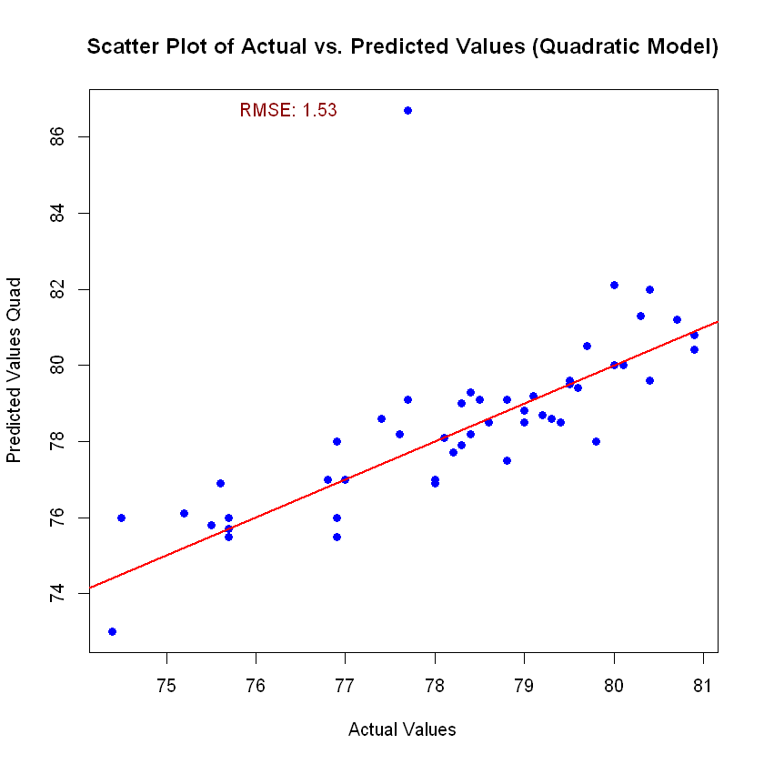

```r
LE2018$PredLE2019Quad2 <- LE2019quadratic2
predicted_values_quad4 <- LE2018$PredLE2019Quad2  # Predicted values from the quadratic model

# Create the scatter plot for the quadratic model predictions
plot(actual_values, predicted_values_quad4,
     xlab = "Actual Values", ylab = "Predicted Values Quad",
     main = "Scatter Plot of Actual vs. Predicted Values (Quadratic Model)",
     pch = 19, col = "blue")  # pch = 19 makes the points solid; col = "blue" colors them blue

# Add a 45-degree line to indicate where actual equals predicted
abline(0, 1, col = "red", lwd = 2)  # lwd = 2 makes the line a bit thicker for visibility

# Calculate RMSE for the quadratic model and add it to the plot
rmse_value_quad <- sqrt(mean((actual_values - predicted_values_quad4)^2, na.rm = TRUE))
text(x = quantile(actual_values, 0.1), y = max(predicted_values_quad4), labels = paste("RMSE:", round(rmse_value_quad, 2)), pos = 4, col = "darkred")
```

Second Order Regression with Interactions RMSE = 1.53

The closer the RSME Value is to zero, the less variation between the actual and predicted values.

(Summary of All RSME Values)

First-order Regression RMSE = 0.94

First-order Regression with Interactions RMSE = 0.85

Second Order Regression RMSE = 0.83

Second Order Regression with Interactions RMSE = 1.53